# Calculating additional variables

Chau Ho

2022-05-12

**Goals:** Let’s add additional variables to our analyses. All new variables are saved in `Calculating additional variables.Rdata` and includes:

- d_quad_neighbors: rust intensity in the neighboring quadrants
- d_quad_rates: rust increase rate for the 2016 season

```r
library(tidyverse)
```

```r
library(ggplot2)
library(DT) # For datatable()
source(file = "Functions/find_peakvalley.R")

### Helpful things
# Used for calculating change in time for rates
all_times = expand.grid(quadrat = c(1:128), year = c(2015:2017), month = c(1:12)) %>%
  mutate(month = ifelse(month < 10, paste("0", month, sep=""), month),
         time = paste(year, month, sep = "-")) %>%
  select(time, quadrat) %>%
  arrange(time)
timesteps = all_times %>% select(time) %>% unique()
timesteps = timesteps %>%
  arrange(time) %>%
  mutate(step = c(1:nrow(timesteps)))

### Rust data
roya = readRDS(file = "data/roya_uniqueplants_20210505.rds")

# Select rust data for 2016 season
d_roya_subset = roya %>%
  filter(year %in% c(2015, 2016, 2017)) %>%
  mutate(inf = ifelse(hojas == 0, NA, roya/hojas),
         month = ifelse(month < 10, paste("0", month, sep=""), month),
         time = paste(year, month, sep = "-")) %>%
  group_by(time, quadrat) %>%
  summarize(inf_avg = mean(inf, na.rm = TRUE), .groups = "drop") %>%
  as.data.frame()

# Fills in missing months
d_roya_subset = all_times %>%
  left_join(d_roya_subset, by = c("time", "quadrat"))
```

# 1 Rust increase rate for the 2016 season

## 1.1 Overall 2016 rust season

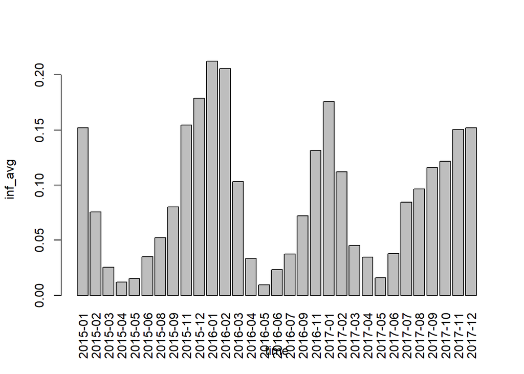

```r
d1 = d_roya_subset %>%
  group_by(time) %>%
  summarize(inf_avg = mean(inf_avg, na.rm = TRUE))

#barplot(inf_avg ~ time, data = d1, las=3) # Looks very similar
barplot(inf_avg ~ time, data = d1, las=3)
```

The rust cycle runs from May through May. Our abiotic variables were collected in Summer 2016, so perhaps we should try to predict the rate of increase in rust from May 2016 - May 2017.

Do individual quadrats vary much in this pattern?

```r
# Plots of individual quadrat; takes too long to run
# ggplot(data = d_roya_subset, aes(x = time, y = inf_avg)) +
#   geom_bar(stat = "identity", color = "blue", alpha = 0.2) +
#   facet_wrap(~quadrat)
```

Yes, there is a wide variation in each quadrat’s trajectory. (Did not show graph because takes too long to generate in every knit.)